# Topic 22

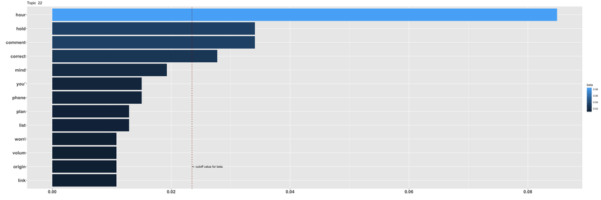

On interpreting beta: the term has a beta probability of being generated from the particular topic.

Values below are gamma : An estimated proportion of words from that document that are generated from that topic.

**Text Record Number: 568** gamma: 12 % likelihood of this document (based on its words) in this topic

**Thank you so much for your comment! I saved it and will start implementing what you said today - thank you

Like you said - work smarter, not harder. I think there’s a common misconception that how productive you are correlates to how many hours you work. I think that’s somewhat true (for the first hours), but it all depends on how you practice (I haven’t been doing any of those things you mentioned though). I saw in an interview that Alexander Malofeev practiced 10 hours a day (all day when possible) and thought, “that should be me.” Unfortunately, I don’t have the stamina or mental capability to be productive for more than 2 hours at a time, and I think Malofeev has trained himself over several years to stay hyper-focused for many hours at a time and has the lifestyle to accommodate that. Anyway thank youu!**

**Text Record Number: 1021** gamma: 12 % likelihood of this document (based on its words) in this topic

**It sounds great! The danger with a lot of Muse stuff is that people play it ridiculously fast to “sound impressive” but you’ve managed to hold your tempo well here. The very end is from Screenager right? You have the start of a great medley idea if so! You should have a crack at space dementia too.

In terms of feedback, watch out at about 0:39 where your LH plays a Db, but at that point I believe it should be Eb. For the pedal, the end section is a bit tricky because you obviously have a ton of dissonance with the chromatic scale, but equally you need the notes to sustain from one octave to the next. I’d argue that the chaos of holding it down throughout the chromatic scale is probably most Muse-like, but maybe split it so that you hold for the first descending single note chromatic scale, then lift and hold again for the octave descent, then lift and hold for the ascent. I’d then make sure you lift and put it back down for when the LH plays the A octaves.

Hope this helps, sounds great though and is one of my favourite Muse songs.**

**Text Record Number: 1383** gamma: 12 % likelihood of this document (based on its words) in this topic

**Hey there,

I started learning piano back in february, made it a little through Alfred’s and then decided on a teacher (only been via zoom so far).

The teaching schedule has looked like this so far:

March:

- Focusing on very simple nursery rhymed and drilling in the FACE/ACEG and how to read the music

April:

- Tackling 1-14 in the Czerny books, following the exact (rather strange and annoying) fingerings (I found this really tough. I hated it but pushed through!

May:

- Bach’s Magdalena book. Focused on learning Minuet in G. This took about 3 weeks practicing an hour a day

June:

- Bach book again, this time learning some other ‘Menuets’ - similar in difficulty. I could do these in around 2 weeks

July:

- Managed to finish a Bach piece (Menuet 132) in 7 days, practicing roughly about 12 hours. I can play with no mistakes.

My worry is that I see a lot of advice on here saying that you shouldn’t be learning songs that you cannot sightread with both hands at (the very least) a low, low tempo. I can do hands apart (with a few mistakes) but DEFINITELY could NOT do these pieces hands together at sight.

So far my teacher has been breaking the pieces into ‘cognitive units’ - telling me to learn them in 4 bar chunks. Right hand first, then left. However, from what I read on here, if it’s taking hours upon hours to learn and perfect, then the piece is probably too hard?

Sure, once it’s in muscle memory, I can play it just fine, but on sight? It’s a different story. I’m worried that perhaps my teacher is pushing me a little too hard? I asked him about this and he said:

“You don’t have to worry - these pieces are hard. Next week we can look at a piece to consolidate your reading. I’d actually prefer you to learn these pieces the way you have been, your progress is perfect. Yes, you’ve done 4 pieces so far, but by the time you’ve learned the 12 I plan the reading aspect will begin to sink in and then we can just work on brushing all the pieces up”

Earlier on, he also said (when I asked about the fact that I’m forgetting the other pieces with each successive one that I learn)

“Cognitively you’ve forgotten it, but it’s in your muslce memory and the nurones have been created! In the future, that’s how you practice sight reading, by reactivating the neurones”

I really like him as a teacher and it’s very clear that I’ve made huge leaps in terms of my ability since getting a teacher, but I’m worried that my sight-reading is completely suckish.**

**Text Record Number: 1335** gamma: 12 % likelihood of this document (based on its words) in this topic

**I don’t know if this is against the rules, but I’m going to study piano in college this year and I can bring myself to practice more than an hour a day. That’s when I DO practice😑 Is anyone’s else struggling with practicing? Maybe we could hold each other accountable!**

**Text Record Number: 363** gamma: 12 % likelihood of this document (based on its words) in this topic

**I would read Payson Method Piano, especially the sections on fixing mistakes and practicing. I used to practice 3 hours a day and feel stuck but using these techniques I practice like 30 min to an hour and make way more progress. Don’t get discouraged, most people encounter this problem. Hope this helps, good luck!

Payson Method Piano by Andrew Payson

https://www.amazon.com/Payson-Method-Piano-Andrew/dp/173293231X/ref=sr\_1\_2?dchild=1&keywords=payson+method+piano&qid=1586154106&sr=8-2**

**Text Record Number: 482** gamma: 12 % likelihood of this document (based on its words) in this topic

**I think learning Beginner pieces by Andrew Payson will help. You can practice half and hour a day and quickly learn these.

http://paysonmethod.com/free-resources/**

**Text Record Number: 396** gamma: 12 % likelihood of this document (based on its words) in this topic

**My longest teacher I was with 4 years. I had two others that lasted 2 years. And then a handful inbetween those that were worse fits**